# Overfishing problematics: How to keep the spearfishing spirit alive in Australia

Arnaud Guerbet

2022-12-30

## Introduction

Spearfishing is a very technical and intensive sport based on the connection of fishes and barbecues. However, this sport become more and more limited by the over fishing we can observed all around the world. Therefore, to save the spearfishing spirit, this study was made to define the best region of Australia for spearfishing based on the biomass, the size and the abundance of the most common fishes family targeted by spearfishing. First, we will compare the total biomass and the family composition among region and then we will focus on the most interesting area to identify the abundance and the size distribution of these different families.

## Materials & Methods

The data were collected all around Australia by underwater visual census (UVC) by SCUBA divers along a 50m transect line. All fish species observed within 5m of the transect line were recorded. In this dataset, seven region (i.e., New South Wales; Western Australia; Tasmania; Victoria; South Australia; Queensland; Other Territories) were recorded and fish abundance, size and biomass were measured. A selection of the most common fishes family (i.e., Carangidae,Haemulidae, Kyphosidae, Labridae, Lethrinidae, Lutjanidae, Mullidae, Scaridae,Serranidae) for spearfishing was performed.

## Code & Analyses

```r
setwd("C:/Users/ASUS/Desktop/NTU_Courses/R courses")
data<-read.csv('data_fish.csv',header=T, sep=",", dec='.')

#MANIPULATE THE DATA
#selection of the column
data2 <- dplyr::select(data,c(4:5,7:9,24:25, 27:29))

#Focus on the family for spearfishing
data3<- data2[data2$family %in% c("Carangidae","Haemulidae", "Kyphosidae","Labridae","Lethrinidae", "Lutjanidae", "Mullidae", "Scaridae","Serranidae"),]
#Arrange table
data3 <- arrange(data3, area)
```

### Selection of region

The other territories were exclude of the study because this region is characterized by only two sites, which is not enough to compare to the other region. Queensland is also characterized by only two sites so a combination of Queensland and New South Wales was chosen to define the Eastern Australia region.

```r
#Exclude Other territories
data3<-data3[c(-6897:-6998),]
#Combine Queensland and New South Wales to Eastern Australia
data3$area[data3$area == 'Queensland'] <- 'Eastern Autralia'
data3$area[data3$area == 'New South Wales'] <- 'Eastern Autralia'
data3 <- arrange(data3, area)#arrange again
```

### Region

First, I decide to focus on the comparison of the fish biomass among region to define which region is more productive than the others. I apply a KruskalWallis test because the homoscedasticity is not accepted here.

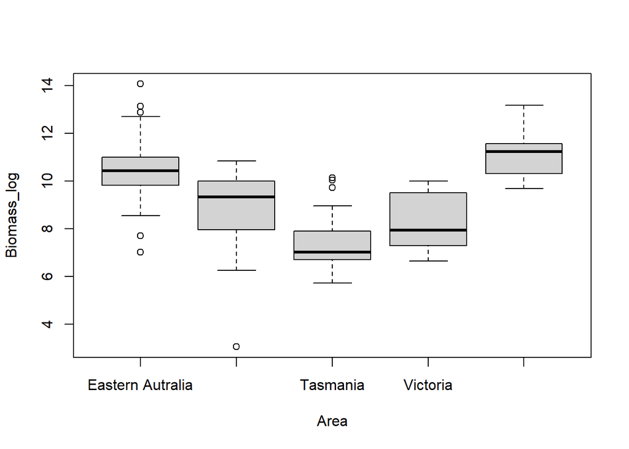

```r
#Sum of the family biomass by site
bio_reg<-aggregate(data3$biomass,list (data3$area,data3$location,data3$ecoregion, data3$site_name),sum, na.rm=TRUE)
colnames(bio_reg)<-c('Area', 'Ecoregion', 'Location', 'Site', 'Biomass')
bio_reg$Biomass_log<-log(bio_reg$Biomass)
boxplot(Biomass_log ~ Area, data = bio_reg)
```

```r
#statistic
bartlett.test(Biomass~Area,data=bio_reg)#No homogeneous variance. So we can not use ANOVA
```

```
##
##  Bartlett test of homogeneity of variances
##
## data:  Biomass by Area
## Bartlett's K-squared = 230.93, df = 4, p-value < 2.2e-16
```

```r
kruskal.test(Biomass ~ Area, data = bio_reg)#Difference between Area
```

```
##
##  Kruskal-Wallis rank sum test
##
## data:  Biomass by Area
## Kruskal-Wallis chi-squared = 92.189, df = 4, p-value < 2.2e-16
```

```r
pairwise.wilcox.test(bio_reg$Biomass, bio_reg$Area, p.adjust.method = "bonferroni")
```

```
##
##  Pairwise comparisons using Wilcoxon rank sum test with continuity correction
##
## data:  bio_reg$Biomass and bio_reg$Area
##
##                   Eastern Autralia South Australia Tasmania Victoria
## South Australia   0.0012           -               -        -
## Tasmania          7.3e-12          0.1387          -        -
## Victoria          9.0e-06          1.0000          0.1739   -
## Western Australia 0.0383           3.4e-06         5.2e-15  1.6e-09
##
## P value adjustment method: bonferroni
```

We can observe that the eastern Australia and Western Australia are the most productive area of spearfishing fish family.

### Family composition

In a second time, we target the diversity and the composition of fish family to estimate in which region we can have the most diversity of taste in our plates. For that, I process a test of proportion (Chi-square test) between regions.

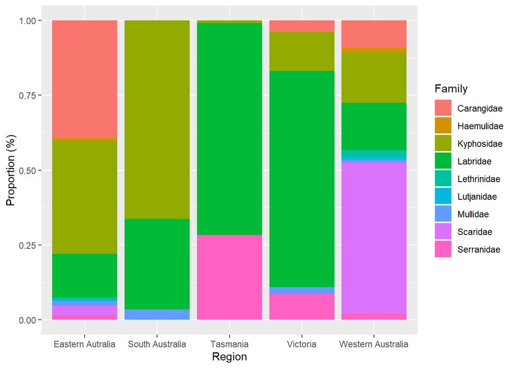

```r
#FISH COMPOSITION
bio_fam<-aggregate(data3$biomass,list (data3$area,data3$family),sum,na.rm=TRUE)
colnames(bio_fam)<-c('Area', 'Family', 'Biomass')

#Graph
ggplot(bio_fam, aes(fill=Family, y=Biomass, x=Area)) +
  geom_bar(position="fill", stat="identity") +
  xlab("Region") +
  ylab("Proportion (%)") +
  labs(fill = "Family")
```

```r
#Test
bio_fam2 <- pivot_wider(bio_fam, names_from = Family, values_from = Biomass)
bio_fam2 <- dplyr::select(bio_fam2,c(2:10))
bio_fam2[is.na(bio_fam2)] <- 0#To be able to run the test I need to have the same number of category between region. So NA value were replace by 0, which is the proportion of biomass observe. In the smapling effort.

row.names(bio_fam2)<-c("Eastern Autralia","Victoria", "Western Australia","South Australia", "Tasmania")
chisq.test(bio_fam2[c(1,2),])
```

```
##
##  Pearson's Chi-squared test
##
## data:  bio_fam2[c(1, 2), ]
## X-squared = 331666, df = 8, p-value < 2.2e-16
```

```r
chisq.test(bio_fam2[c(1,3),])
```

```
##
##  Pearson's Chi-squared test
##
## data:  bio_fam2[c(1, 3), ]
## X-squared = 3628015, df = 8, p-value < 2.2e-16
```

```r
chisq.test(bio_fam2[c(1,4),])
```

```
##
##  Pearson's Chi-squared test
##
## data:  bio_fam2[c(1, 4), ]
## X-squared = 153126, df = 8, p-value < 2.2e-16
```

```r
chisq.test(bio_fam2[c(1,5),])
```

```
##
##  Pearson's Chi-squared test
##
## data:  bio_fam2[c(1, 5), ]
## X-squared = 689968, df = 8, p-value < 2.2e-16
```

```r
chisq.test(bio_fam2[c(2,3),])
```

```
##
##  Pearson's Chi-squared test
##
## data:  bio_fam2[c(2, 3), ]
## X-squared = 284265, df = 8, p-value < 2.2e-16
```

```r
chisq.test(bio_fam2[c(2,4),])
```

```
##
##  Pearson's Chi-squared test
##
## data:  bio_fam2[c(2, 4), ]
## X-squared = NaN, df = 8, p-value = NA
```

```r
chisq.test(bio_fam2[c(2,5),])
```

```
##
##  Pearson's Chi-squared test
##
## data:  bio_fam2[c(2, 5), ]
## X-squared = NaN, df = 8, p-value = NA
```

```r
chisq.test(bio_fam2[c(3,4),])
```

```
##
##  Pearson's Chi-squared test
##
## data:  bio_fam2[c(3, 4), ]
## X-squared = 369753, df = 8, p-value < 2.2e-16
```

```r
chisq.test(bio_fam2[c(3,5),])
```

```
##
##  Pearson's Chi-squared test
##
## data:  bio_fam2[c(3, 5), ]
## X-squared = 508096, df = 8, p-value < 2.2e-16
```

```r
chisq.test(bio_fam2[c(4,5),])
```

```
##
##  Pearson's Chi-squared test
##
## data:  bio_fam2[c(4, 5), ]
## X-squared = NaN, df = 8, p-value = NA
```

```r
data4<-data3[c(-7054:-8569),]#Keep only Eastern and Western Australia
fit1 <- lm(biomass ~ size_class + total, data = na.omit(data4))
summary(fit1)
```

```
##
## Call:
## lm(formula = biomass ~ size_class + total, data = na.omit(data4))
##
## Residuals:
##     Min      1Q  Median      3Q     Max
## -111353    -448     259     709  155973
##
## Coefficients:
##              Estimate Std. Error t value Pr(>|t|)
## (Intercept) -1950.152     73.385  -26.57   <2e-16 ***
## size_class    105.715      3.855   27.42   <2e-16 ***
## total         158.076      1.172  134.83   <2e-16 ***
## ---
## Signif. codes:  0 '***' 0.001 '**' 0.01 '*' 0.05 '.' 0.1 ' ' 1
##
## Residual standard error: 4656 on 12570 degrees of freedom
## Multiple R-squared:  0.5969, Adjusted R-squared:  0.5969
## F-statistic:  9309 on 2 and 12570 DF,  p-value: < 2.2e-16
```

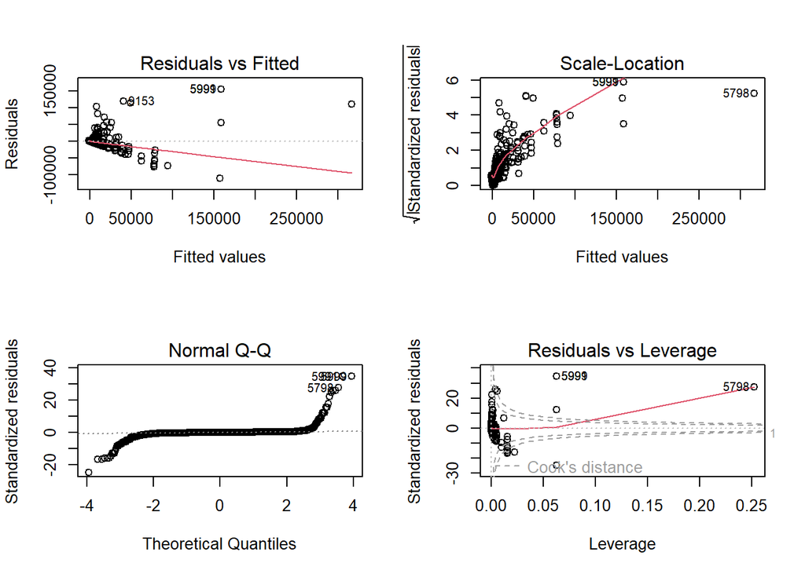

```r
layout(matrix(c(1,2,3,4),2,2))
plot(fit1)
```

```r
#boxcox transformation
boxcoxfit <- boxcox(fit1,plotit=T)
lambda <- boxcoxfit$x[which.max(boxcoxfit$y)]
new_fit <- lm(((data4$biomass^lambda-1)/lambda) ~ size_class + total, data = data4)
new_fit2 <- lm(log(data4$biomass) ~ size_class + total, data = data4)
gvlma(new_fit)#not better at all
```

```
##
## Call:
## lm(formula = ((data4$biomass^lambda - 1)/lambda) ~ size_class +
##     total, data = data4)
##
## Coefficients:
## (Intercept)   size_class        total
##     2.69158      0.21180      0.03024
##
##
## ASSESSMENT OF THE LINEAR MODEL ASSUMPTIONS
## USING THE GLOBAL TEST ON 4 DEGREES-OF-FREEDOM:
## Level of Significance =  0.05
##
## Call:
##  gvlma(x = new_fit)
##
##                        Value   p-value                   Decision
## Global Stat        1.293e+05 0.000e+00 Assumptions NOT satisfied!
## Skewness           6.143e+01 4.552e-15 Assumptions NOT satisfied!
## Kurtosis           1.262e+05 0.000e+00 Assumptions NOT satisfied!
## Link Function      3.021e+03 0.000e+00 Assumptions NOT satisfied!
## Heteroscedasticity 3.705e+00 5.425e-02    Assumptions acceptable.
```

```r
gvlma(new_fit2)#not better at all
```

```
##
## Call:
## lm(formula = log(data4$biomass) ~ size_class + total, data = data4)
##
## Coefficients:
## (Intercept)   size_class        total
##     2.50443      0.12916      0.01526
##
##
## ASSESSMENT OF THE LINEAR MODEL ASSUMPTIONS
## USING THE GLOBAL TEST ON 4 DEGREES-OF-FREEDOM:
## Level of Significance =  0.05
##
## Call:
##  gvlma(x = new_fit2)
##
##                        Value p-value                   Decision
## Global Stat        48082.774  0.0000 Assumptions NOT satisfied!
## Skewness             975.055  0.0000 Assumptions NOT satisfied!
## Kurtosis           43831.340  0.0000 Assumptions NOT satisfied!
## Link Function       3274.720  0.0000 Assumptions NOT satisfied!
## Heteroscedasticity     1.659  0.1977    Assumptions acceptable.
```

```r
#bootstrap
sqrt(car::vif(fit1))#<2 so okay
```

```
## size_class      total
##   1.001163   1.001163
```

```r
fit2 <- Boot(fit1, f=coef, R=1000, method=c("case"))
summary(fit2, high.moments=T)
```

```
##
## Number of bootstrap replications R = 1000
##             original bootBias   bootSE  bootMed  bootSkew bootKurtosis
## (Intercept) -1950.15  38.4576 227.3675 -1934.06  0.575410      0.25700
## size_class    105.71  -1.0159   7.7353   104.77 -0.074189      0.11582
## total         158.08  -3.4197  24.0656   157.24 -0.621785      0.24049
```

[figure not shown]

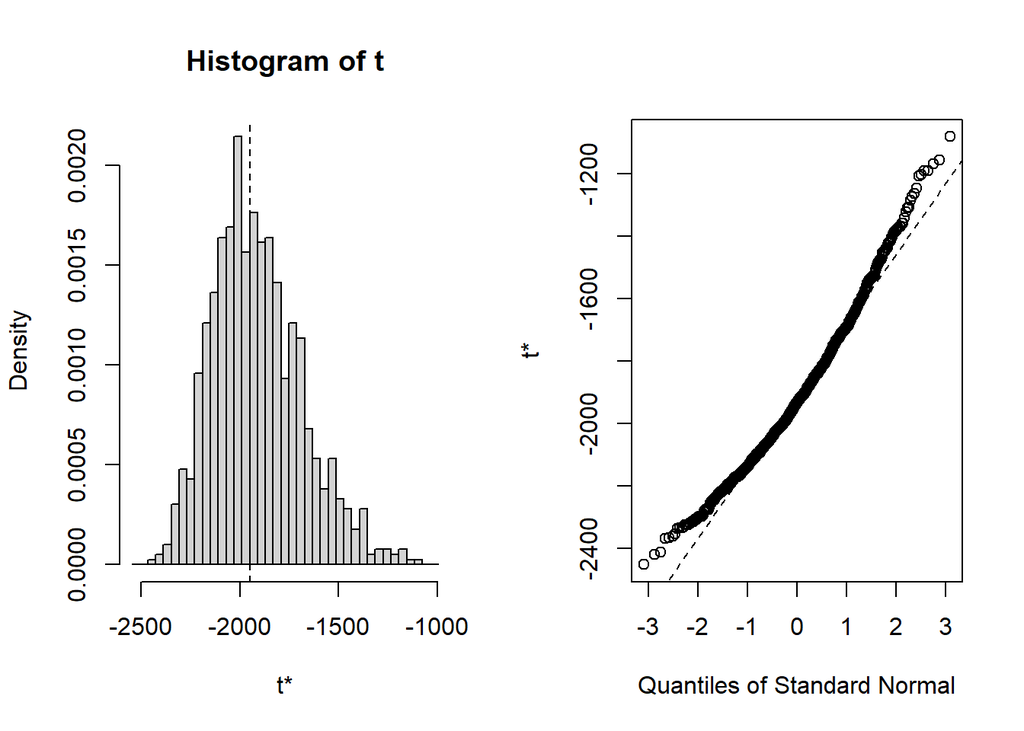

```r
plot(fit2)#Looks okay.
```

```r
#Selection variables
mod1<-lm(biomass ~ size_class + total, data = na.omit(data4))
mod2<-lm(biomass ~ size_class, data = na.omit(data4))
mod3<-lm(biomass ~ total, data = na.omit(data4))

anova(mod1,mod2)
```

```
## Analysis of Variance Table
##
## Model 1: biomass ~ size_class + total
## Model 2: biomass ~ size_class
##   Res.Df        RSS Df   Sum of Sq     F    Pr(>F)
## 1  12570 2.7245e+11
## 2  12571 6.6646e+11 -1 -3.9401e+11 18178 < 2.2e-16 ***
## ---
## Signif. codes:  0 '***' 0.001 '**' 0.01 '*' 0.05 '.' 0.1 ' ' 1
```

```r
anova(mod1,mod3)
```

```
## Analysis of Variance Table
##
## Model 1: biomass ~ size_class + total
## Model 2: biomass ~ total
##   Res.Df        RSS Df   Sum of Sq      F    Pr(>F)
## 1  12570 2.7245e+11
## 2  12571 2.8875e+11 -1 -1.6298e+10 751.93 < 2.2e-16 ***
## ---
## Signif. codes:  0 '***' 0.001 '**' 0.01 '*' 0.05 '.' 0.1 ' ' 1
```

```r
anova(mod2,mod3)
```

```
## Analysis of Variance Table
##
## Model 1: biomass ~ size_class
## Model 2: biomass ~ total
##   Res.Df        RSS Df  Sum of Sq F Pr(>F)
## 1  12571 6.6646e+11
## 2  12571 2.8875e+11  0 3.7771e+11
```

```r
BIC(mod1); BIC(mod2); BIC(mod3)
```

```
## [1] 248094.2
```

```
## [1] 259331.6
```

```
## [1] 248815.3
```

```r
AIC(mod1); AIC(mod2); AIC(mod3)
```

```
## [1] 248064.5
```

```
## [1] 259309.3
```

```
## [1] 248793
```

```r
step1 <- stepAIC(fit1, direction="both")
```

```
## Start:  AIC=212381.9
## biomass ~ size_class + total
##
##              Df  Sum of Sq        RSS    AIC
## <none>                     2.7245e+11 212382
## - size_class  1 1.6298e+10 2.8875e+11 213110
## - total       1 3.9401e+11 6.6646e+11 223627
```

```r
step1$anova
```

```
## Stepwise Model Path
## Analysis of Deviance Table
##
## Initial Model:
## biomass ~ size_class + total
##
## Final Model:
## biomass ~ size_class + total
##
##
##   Step Df Deviance Resid. Df   Resid. Dev      AIC
## 1                      12570 272452453043 212381.9
```

```r
n<-dim(data3)[1]
step2 <- stepAIC(fit1, k=log(n), direction="both")
```

```
## Start:  AIC=212404.5
## biomass ~ size_class + total
##
##              Df  Sum of Sq        RSS    AIC
## <none>                     2.7245e+11 212405
## - size_class  1 1.6298e+10 2.8875e+11 213125
## - total       1 3.9401e+11 6.6646e+11 223642
```

```r
step2$anova
```

```
## Stepwise Model Path
## Analysis of Deviance Table
##
## Initial Model:
## biomass ~ size_class + total
##
## Final Model:
## biomass ~ size_class + total
##
##
##   Step Df Deviance Resid. Df   Resid. Dev      AIC
## 1                      12570 272452453043 212404.5
```

So both of the factor, size and abundance explain the biomass of fish in the two part of Australia. So now, we’ll try to compare the size and abundance of fish in the two regions.

### focus on the size and the abundance in West and Eastern of Australia.

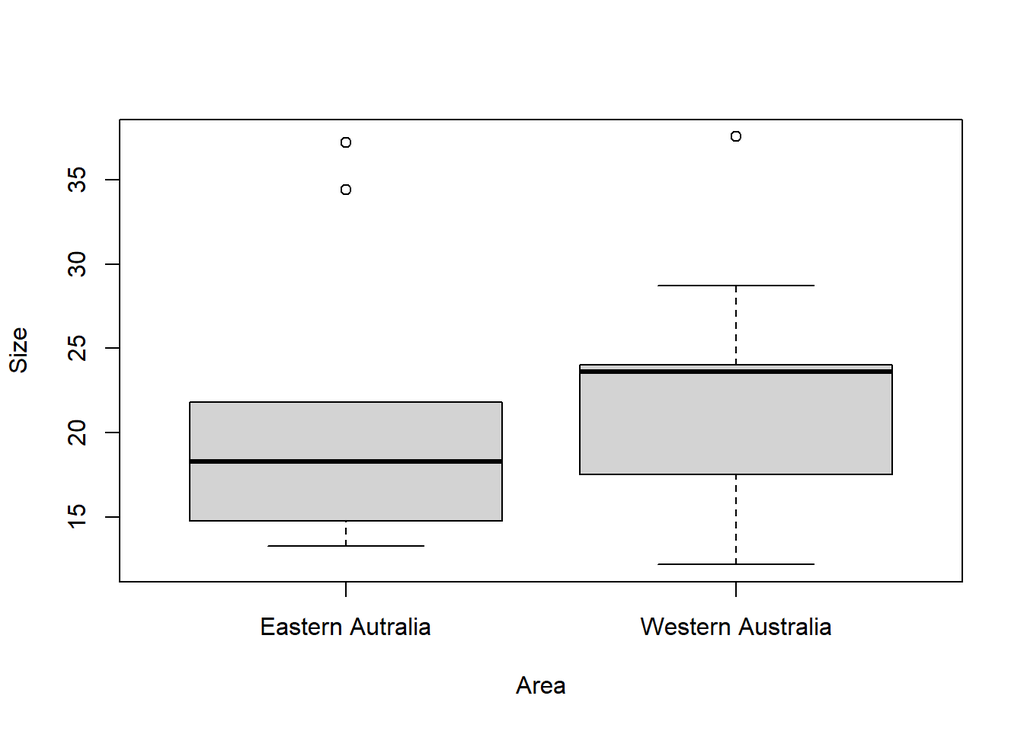

```r
#SIZE-CLASS
#By region
size_fam<-aggregate(data4$size_class,list (data4$area,data4$family),mean,na.rm=TRUE)
colnames(size_fam)<-c('Area', 'Family', 'Size')
boxplot(Size ~ Area, data = size_fam)
```

```r
bartlett.test(Size ~ Area, data = size_fam)
```

```
##
##  Bartlett test of homogeneity of variances
##
## data:  Size by Area
## Bartlett's K-squared = 0.16305, df = 1, p-value = 0.6864
```

```r
shapiro.test(size_fam$Size)
```

```
##
##  Shapiro-Wilk normality test
##
## data:  size_fam$Size
## W = 0.8911, p-value = 0.0403
```

```r
kruskal.test(Size ~ Area, data = size_fam)#No difference between Area
```

```
##
##  Kruskal-Wallis rank sum test
##
## data:  Size by Area
## Kruskal-Wallis chi-squared = 0.56335, df = 1, p-value = 0.4529
```

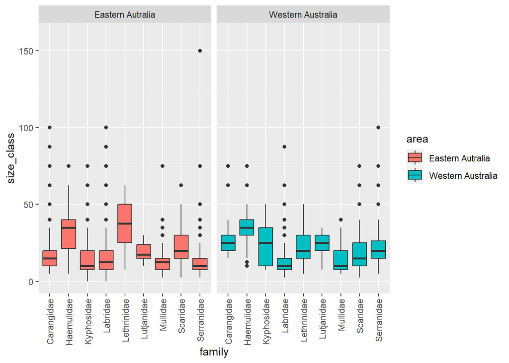

```r
#by Region and Family
ggplot(data4, aes(x=family, y=size_class, fill=area)) +
  geom_boxplot() +
  ylim(0, 160)+
  facet_wrap(~area)+
  theme(axis.text.x = element_text(angle=90, vjust=.5, hjust=1))
```

```r
#East
data_east<-data4[c(0:7053),]
bartlett.test(size_class ~ family, data = data_east)
```

```
##
##  Bartlett test of homogeneity of variances
##
## data:  size_class by family
## Bartlett's K-squared = 161.1, df = 8, p-value < 2.2e-16
```

```r
kruskal.test(size_class ~ family, data = data_east)
```

```
##
##  Kruskal-Wallis rank sum test
##
## data:  size_class by family
## Kruskal-Wallis chi-squared = 356.16, df = 8, p-value < 2.2e-16
```

```r
pairwise.wilcox.test(data_east$size_class, data_east$family, p.adjust.method = "bonferroni")
```

```
##
##  Pairwise comparisons using Wilcoxon rank sum test with continuity correction
##
## data:  data_east$size_class and data_east$family
##
##             Carangidae Haemulidae Kyphosidae Labridae Lethrinidae Lutjanidae
## Haemulidae  1.4e-07    -          -          -        -           -
## Kyphosidae  2.0e-11    3.8e-13    -          -        -           -
## Labridae    1.3e-06    2.7e-13    4.8e-08    -        -           -
## Lethrinidae 1.8e-06    1.00000    1.1e-08    3.4e-09  -           -
## Lutjanidae  1.00000    0.00176    0.00906    0.04030  0.00046     -
## Mullidae    1.2e-10    1.1e-14    1.00000    0.00576  2.7e-10     0.00085
## Scaridae    0.00021    4.7e-05    < 2e-16    < 2e-16  0.00017     1.00000
## Serranidae  7.6e-12    3.7e-14    1.00000    6.1e-05  7.5e-10     0.00028
##             Mullidae Scaridae
## Haemulidae  -        -
## Kyphosidae  -        -
## Labridae    -        -
## Lethrinidae -        -
## Lutjanidae  -        -
## Mullidae    -        -
## Scaridae    < 2e-16  -
## Serranidae  1.00000  < 2e-16
##
## P value adjustment method: bonferroni
```

```r
#West
data_west<-data4[c(7054:14127),]
bartlett.test(size_class ~ family, data = data_west)
```

```
##
##  Bartlett test of homogeneity of variances
##
## data:  size_class by family
## Bartlett's K-squared = 146.71, df = 8, p-value < 2.2e-16
```

```r
kruskal.test(size_class ~ family, data = data_west)
```

```
##
##  Kruskal-Wallis rank sum test
##
## data:  size_class by family
## Kruskal-Wallis chi-squared = 872.39, df = 8, p-value < 2.2e-16
```

```r
pairwise.wilcox.test(data_west$size_class, data_west$family, p.adjust.method = "bonferroni")
```

```
##
##  Pairwise comparisons using Wilcoxon rank sum test with continuity correction
##
## data:  data_west$size_class and data_west$family
##
##             Carangidae Haemulidae Kyphosidae Labridae Lethrinidae Lutjanidae
## Haemulidae  0.00085    -          -          -        -           -
## Kyphosidae  1.00000    3.8e-07    -          -        -           -
## Labridae    < 2e-16    < 2e-16    < 2e-16    -        -           -
## Lethrinidae 0.01446    2.0e-13    1.00000    < 2e-16  -           -
## Lutjanidae  1.00000    1.3e-05    1.00000    4.6e-09  1.00000     -
## Mullidae    6.3e-13    < 2e-16    1.9e-12    0.03334  2.8e-13     3.8e-06
## Scaridae    1.2e-08    < 2e-16    2.7e-06    < 2e-16  5.2e-06     0.01140
## Serranidae  0.02299    7.0e-13    1.00000    < 2e-16  1.00000     1.00000
##             Mullidae Scaridae
## Haemulidae  -        -
## Kyphosidae  -        -
## Labridae    -        -
## Lethrinidae -        -
## Lutjanidae  -        -
## Mullidae    -        -
## Scaridae    1.3e-06  -
## Serranidae  < 2e-16  7.5e-11
##
## P value adjustment method: bonferroni
```

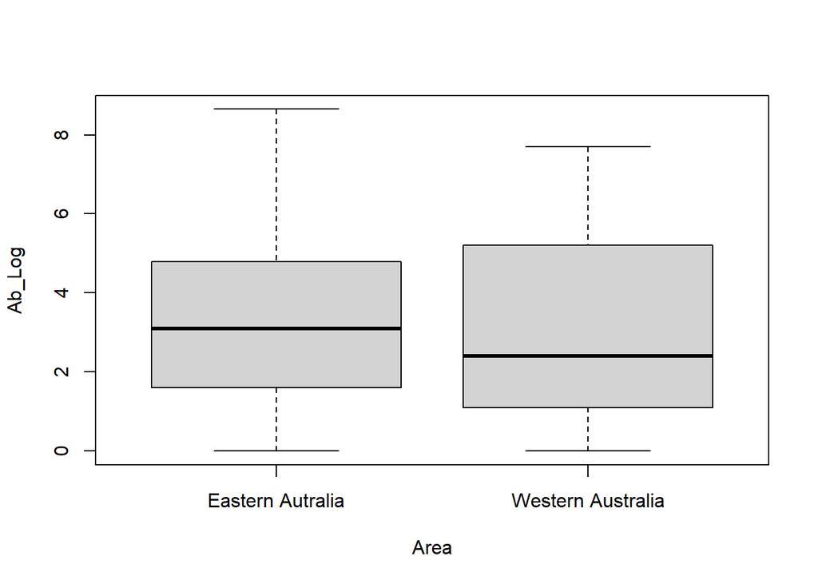

```r
#ABUNDANCE
#By region
ab_fam<-aggregate(data4$total,list (data4$area,data4$site_name,data4$family),sum,na.rm=TRUE)#abundance per site
colnames(ab_fam)<-c('Area', 'Site', 'Family', 'Abundance')
ab_fam$Ab_Log<-log(ab_fam$Abundance)

boxplot(Ab_Log ~ Area, data = ab_fam)
```

```r
bartlett.test(Abundance ~ Area, data = ab_fam)#No homogeneous variance. So cannot use ANOVA
```

```
##
##  Bartlett test of homogeneity of variances
##
## data:  Abundance by Area
## Bartlett's K-squared = 45.113, df = 1, p-value = 1.86e-11
```

```r
wilcox.test(Abundance ~ Area, data = ab_fam)#No difference between Area
```

```
##
##  Wilcoxon rank sum test with continuity correction
##
## data:  Abundance by Area
## W = 47518, p-value = 0.1855
## alternative hypothesis: true location shift is not equal to 0
```

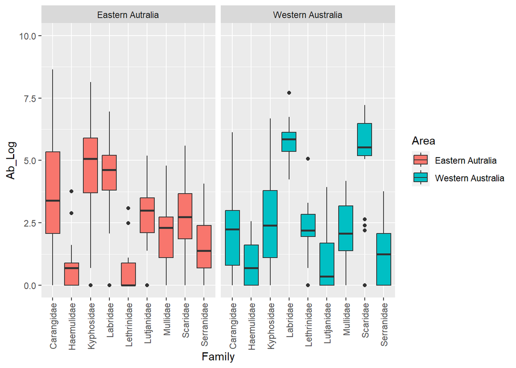

```r
#by Region and Family
ggplot(ab_fam, aes(x=Family, y=Ab_Log, fill=Area)) +
  geom_boxplot() +
  ylim(0, 10)+
  facet_wrap(~Area)+
  theme(axis.text.x = element_text(angle=90, vjust=.5, hjust=1))
```

```r
ab_fam <- arrange(ab_fam, Area)

#East
ab_fam_east<-ab_fam[c(0:406),]
bartlett.test(Abundance ~ Family, data = ab_fam_east)#No homogeneous variance. So cannot use ANOVA
```

```
##
##  Bartlett test of homogeneity of variances
##
## data:  Abundance by Family
## Bartlett's K-squared = 1116.4, df = 8, p-value < 2.2e-16
```

```r
kruskal.test(Abundance ~ Family, data = ab_fam_east)
```

```
##
##  Kruskal-Wallis rank sum test
##
## data:  Abundance by Family
## Kruskal-Wallis chi-squared = 195.18, df = 8, p-value < 2.2e-16
```

```r
pairwise.wilcox.test(ab_fam_east$Abundance, ab_fam_east$Family, p.adjust.method = "bonferroni")
```

```
##
##  Pairwise comparisons using Wilcoxon rank sum test with continuity correction
##
## data:  ab_fam_east$Abundance and ab_fam_east$Family
##
##             Carangidae Haemulidae Kyphosidae Labridae Lethrinidae Lutjanidae
## Haemulidae  2.6e-06    -          -          -        -           -
## Kyphosidae  0.05196    9.7e-10    -          -        -           -
## Labridae    0.51476    7.2e-11    1.00000    -        -           -
## Lethrinidae 0.00244    1.00000    4.4e-05    8.1e-06  -           -
## Lutjanidae  1.00000    0.19881    0.34595    0.20828  0.56192     -
## Mullidae    0.00540    0.00031    2.8e-13    < 2e-16  0.04621     1.00000
## Scaridae    1.00000    0.00011    4.1e-05    2.2e-06  0.01345     1.00000
## Serranidae  9.7e-05    0.00564    9.1e-15    < 2e-16  0.16857     1.00000
##             Mullidae Scaridae
## Haemulidae  -        -
## Kyphosidae  -        -
## Labridae    -        -
## Lethrinidae -        -
## Lutjanidae  -        -
## Mullidae    -        -
## Scaridae    1.00000  -
## Serranidae  1.00000  0.07117
##
## P value adjustment method: bonferroni
```

```r
#West
ab_fam_west<-ab_fam[c(406:626),]
bartlett.test(Abundance ~ Family, data = ab_fam_west)#No homogeneous variance. So cannot use ANOVA
```

```
##
##  Bartlett test of homogeneity of variances
##
## data:  Abundance by Family
## Bartlett's K-squared = 602.35, df = 8, p-value < 2.2e-16
```

```r
kruskal.test(Abundance ~ Family, data = ab_fam_west)
```

```
##
##  Kruskal-Wallis rank sum test
##
## data:  Abundance by Family
## Kruskal-Wallis chi-squared = 134.77, df = 8, p-value < 2.2e-16
```

```r
pairwise.wilcox.test(ab_fam_west$Abundance, ab_fam_west$Family, p.adjust.method = "bonferroni")
```

[output not shown]

[output cut: 52 more lines]

[output not shown]

```
##
##  Pairwise comparisons using Wilcoxon rank sum test with continuity correction
##
## data:  ab_fam_west$Abundance and ab_fam_west$Family
##
##             Carangidae Haemulidae Kyphosidae Labridae Lethrinidae Lutjanidae
## Haemulidae  0.48101    -          -          -        -           -
## Kyphosidae  1.00000    0.31636    -          -        -           -
## Labridae    0.00016    9.7e-09    3.3e-06    -        -           -
## Lethrinidae 1.00000    0.00612    1.00000    1.4e-08  -           -
## Lutjanidae  0.78382    1.00000    1.00000    8.3e-06  0.16021     -
## Mullidae    1.00000    0.00470    1.00000    7.7e-12  1.00000     0.14494
## Scaridae    0.00680    9.4e-07    0.00050    1.00000  1.5e-05     0.00017
## Serranidae  1.00000    1.00000    1.00000    1.7e-11  0.14510     1.00000
##             Mullidae Scaridae
## Haemulidae  -        -
## Kyphosidae  -        -
## Labridae    -        -
## Lethrinidae -        -
## Lutjanidae  -        -
## Mullidae    -        -
## Scaridae    3.0e-07  -
## Serranidae  0.11429  3.5e-08
##
## P value adjustment method: bonferroni
```

In term of abundance, we do not observe any difference of abundance between East and West Australia. But by region, we observe a dominance of Kyphosidae, Labridae and Carangidae in Eastern Australia. In western Australia, we can see a clear dominance of Labridae and Scaridae.

## Discussion

The result shown that the Eastern and Western Australia are the most productive region of Australia in term of fishes targeted for spearfishing. This result can be explain by the position of the region which are between tropical and subtropical environment increasing the diversity of species by integrating tropical and subtropical species. Indeed, the fish composition of this two regions is the most diversify compare to the others. The location of the region between two climate aera can explain this particularity. When we focus in the two regions.

In eastern Australia, we saw a dominance of Kyphosidae, Carangidae and Labridae. These three family are explained by a low size but it present the highest abundance compare to other family. So spear fisherman expert of the strategy “many small fishes” can seems to be more productive in Eastern Australia. The dominant families of Western Australia are Scaridae, Kyphosidae , and Labridae. These three species present different type of distribution. Scaridae show a middle size compare to other families and a very high abundance, that’s why it define more than 50% of the total biomass. Kyphosidae species are bigger but present a lower abundance in this region. At the opposite, Labridae species are small but very abundance. This two opposite distribution present a similar effect on the total biomass showing a very similar value to total biomass proportion in the region. So Western Australia can be a good place for spear fisherman who can play the two strategies, “many small fishes” and “few big fishes”. The difference of family composition of the two regions can also help the spear fisherman to chose according to their taste.

Obviously, this study focus on a large scale analysis and does not allow to observe the fish composition and biomass at the local scale. It is up to the fishermen to explore the area to find the best spots.